# Powerball Lottery Analysis: A Quantitative Approach

Data Analyst Portfolio

2026-01-18

## 1. Introduction

The Powerball lottery is a game of independent random events. However, historical data often reveals patterns in variance, frequency, and distribution that are interesting from a data science perspective.

In this project, we analyze historical Powerball winning numbers to determine:

1. Which numbers appear most frequently (“Hot” numbers).
2. The distribution of the *sum* of winning numbers.
3. The parity balance (Odd vs. Even ratios).
4. A theoretical Poisson model for predicting jackpot winners.

## 2. Data Loading and Cleaning

We begin by loading the raw dataset and transforming the single string of winning numbers into usable numeric columns.

*Note: Please ensure the CSV file path below matches the location on your computer.*

```r
# Load the data (Adjust path as necessary)
# If the file is in your Downloads folder, you may need to update the path below:
pball_raw <- read_csv("Lottery_Powerball_Winning_Numbers__Beginning_2010.csv")

# Clean and separate the 'Winning Numbers' column
pball_clean <- pball_raw %>%
  separate(`Winning Numbers`,
           into = c("W1", "W2", "W3", "W4", "W5", "PB"),
           sep = " ",
           convert = TRUE)

# Preview the tidy data
head(pball_clean)
```

```
## # A tibble: 6 × 8
##   `Draw Date`    W1    W2    W3    W4    W5    PB Multiplier
##   <chr>       <int> <int> <int> <int> <int> <int>      <dbl>
## 1 09/26/2020     11    21    27    36    62    24          3
## 2 09/30/2020     14    18    36    49    67    18          2
## 3 10/03/2020     18    31    36    43    47    20          2
## 4 10/07/2020      6    24    30    53    56    19          2
## 5 10/10/2020      5    18    23    40    50    18          3
## 6 10/14/2020     21    37    52    53    58     5          2
```

## 3. Frequency Analysis: “Hot” Numbers

Although every number has an equal probability of being drawn, variance ensures some numbers appear more often in the historical sample.

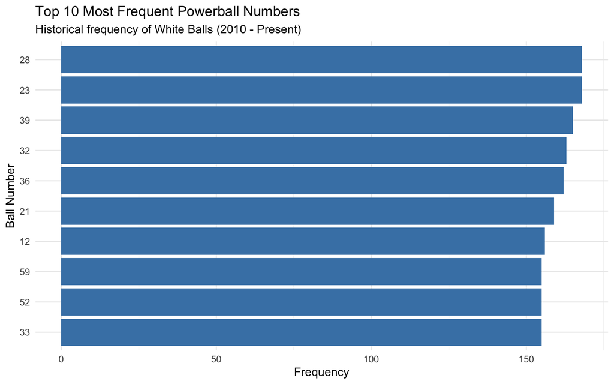

```r
# Pivot to long format to count all white balls together
white_ball_freq <- pball_clean %>%
  pivot_longer(cols = W1:W5, names_to = "ball_pos", values_to = "number") %>%
  count(number, sort = TRUE)

# Visualize the Top 10
ggplot(white_ball_freq[1:10,], aes(x = reorder(number, n), y = n)) +
  geom_col(fill = "steelblue") +
  coord_flip() +
  labs(title = "Top 10 Most Frequent Powerball Numbers",
       subtitle = "Historical frequency of White Balls (2010 - Present)",
       x = "Ball Number",
       y = "Frequency") +
  theme_minimal()
```

## 4. Distribution of Sums

Many lottery strategies involve tracking the sum of the drawn numbers. We analyze whether the sums follow a normal distribution (Bell Curve).

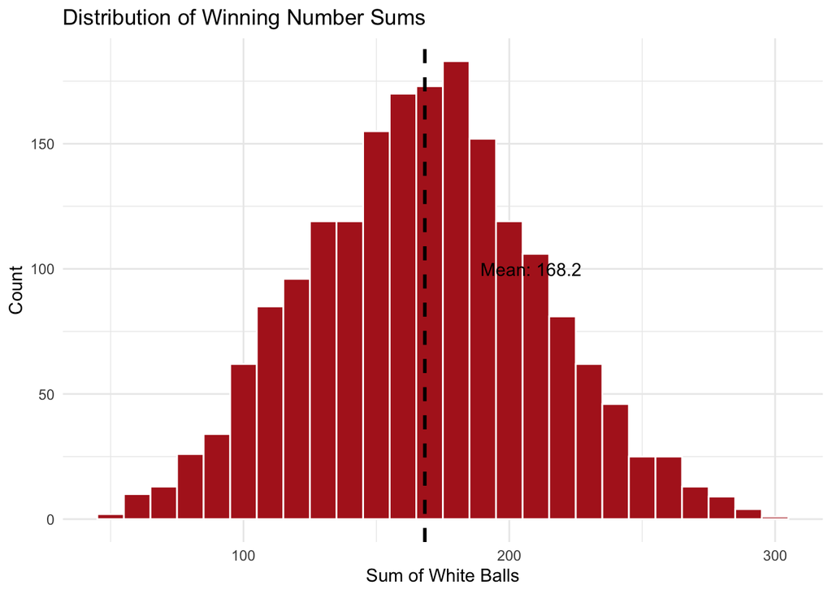

```r
# Calculate row sums
pball_sums <- pball_clean %>%
  mutate(total_sum = W1 + W2 + W3 + W4 + W5)

# Calculate statistics
avg_sum <- mean(pball_sums$total_sum)
med_sum <- median(pball_sums$total_sum)

# Visualization
ggplot(pball_sums, aes(x = total_sum)) +
  geom_histogram(binwidth = 10, fill = "firebrick", color = "white") +
  geom_vline(xintercept = avg_sum, linetype="dashed", size=1) +
  annotate("text", x = avg_sum + 40, y = 100, label = paste("Mean:", round(avg_sum, 1))) +
  labs(title = "Distribution of Winning Number Sums",
       x = "Sum of White Balls",
       y = "Count") +
  theme_minimal()
```

## 5. Strategic Balance: Odd vs. Even

Is it wise to pick all odd numbers? We analyze the ratio of odd-to-even numbers in historical draws.

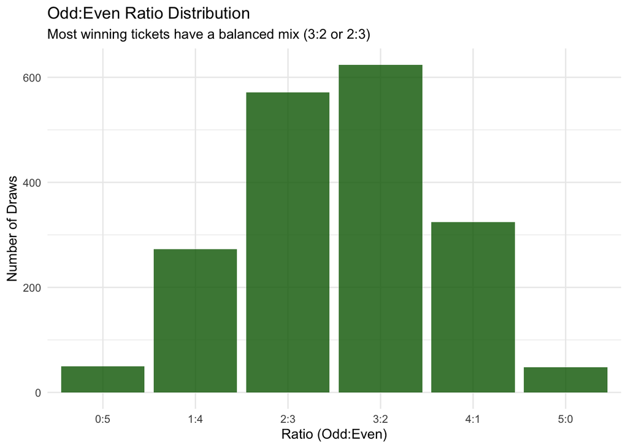

```r
# Calculate Odd vs Even counts per draw
pball_parity <- pball_clean %>%
  rowwise() %>%
  mutate(
    num_odd = sum(c(W1, W2, W3, W4, W5) %% 2 != 0),
    num_even = 5 - num_odd,
    ratio = paste(num_odd, num_even, sep = ":")
  ) %>%
  ungroup()

# Visualize
ggplot(pball_parity, aes(x = ratio)) +
  geom_bar(fill = "darkgreen", alpha = 0.8) +
  labs(title = "Odd:Even Ratio Distribution",
       subtitle = "Most winning tickets have a balanced mix (3:2 or 2:3)",
       x = "Ratio (Odd:Even)",
       y = "Number of Draws") +
  theme_minimal()
```

## 6. Quantitative Modeling: Poisson Distribution

In quantitative finance, calculating the Expected Value (EV) of a ticket requires knowing the probability of splitting the jackpot. We model the number of winners using a Poisson distribution, assuming **150 million** tickets sold.

$$P(X=k) = \frac{\lambda^k
e^{-\lambda}}{k!}$$

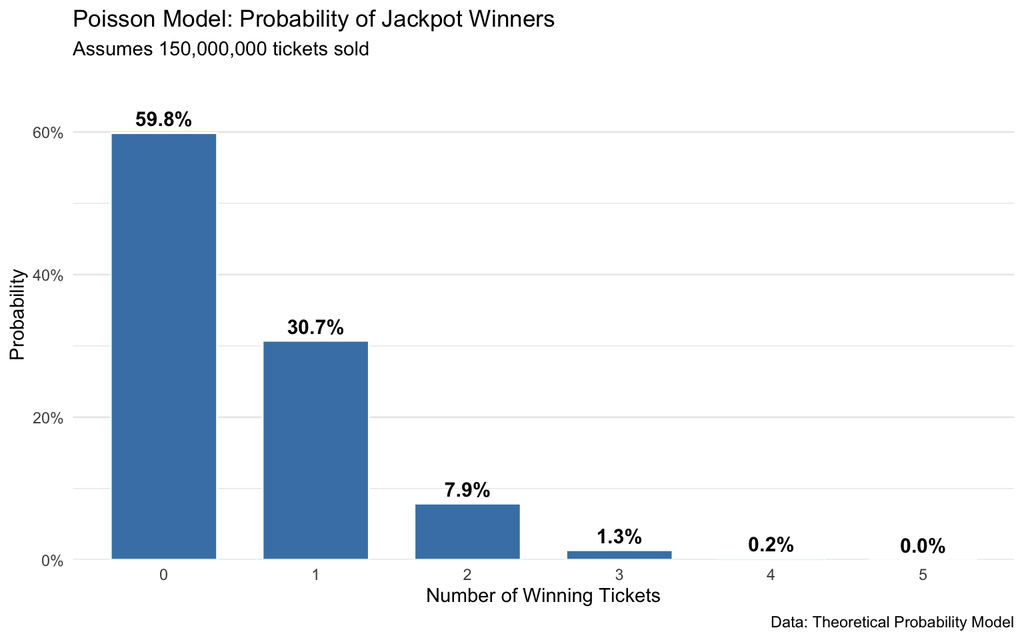

```r
# 1. Setup parameters
p_win <- 1 / 292201338
tickets_sold <- 150000000
lambda <- tickets_sold * p_win

# 2. Generate Probabilities
outcomes <- data.frame(winners = 0:5) %>%
  mutate(prob = dpois(winners, lambda))

# 3. Visualization
ggplot(outcomes, aes(x = factor(winners), y = prob)) +
  geom_col(fill = "steelblue", color = "white", width = 0.7) +
  geom_text(aes(label = percent(prob, accuracy = 0.1)),
            vjust = -0.5, size = 4, fontface = "bold") +
  scale_y_continuous(labels = percent_format(),
                     expand = expansion(mult = c(0, 0.15))) +
  labs(
    title = "Poisson Model: Probability of Jackpot Winners",
    subtitle = paste0("Assumes ", comma(tickets_sold), " tickets sold"),
    x = "Number of Winning Tickets",
    y = "Probability",
    caption = "Data: Theoretical Probability Model"
  ) +
  theme_minimal() +
  theme(panel.grid.major.x = element_blank())
```